# Project Proposal

Seokjun Choi and Sho Kawano

2021-11-28

# Changed Dataset

- Similar but different research questions
- Examine how athletes & non-athletes were affected by COVID-19.
- Online Survey Data Collected as the UK + Ireland emerged from COVID-19 Lockdowns
  - Taken 14-16 weeks after lockdowns. June/July 2020.
  - n=753 (# of complete cases: 457)

# Data Description: Factors

# Data Description: Numeric

- Hours Sleep. Theoretical: >0 hours / Realized: 1.5-10.5.
- Athlete Identification Index (AIMS). Th & Re: 1-7.*
- Anxiety & Depression Scale (HADS). Th: 0-42 / Re: 0-36*.
- Brief Resilience Scale (RES). Th: 0-30 /Re: 6-30*
- Loneliness Scale (LONE) Th & Re: 0-6*
- *Response:* MHC-SF. Represents overall well-being. Th: 0-84 / Re: 2-70 *

* Theoretical/Realized Range

# Main Research Questions

- Were athletes and non-athletes affected from COVID-19 lockdown/social distancing in the same way?
- Are there sex-based differences in the effects of COVID-19 on mental health?
- Under controlled demographic information, what is the relationship between MH-SF index and other sub-indices in this survey?
- Are there additional variables having strong relationship with MH-SF index?

# EDA

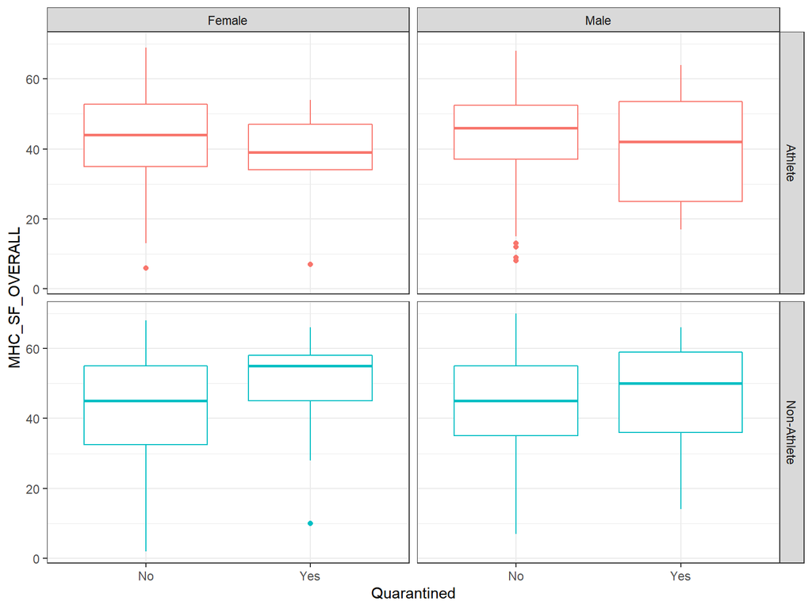

Quarantined

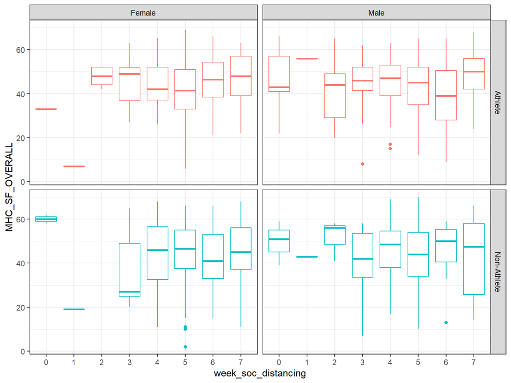

Weeks Social Distancing

# EDA

MHC_SF ~ HADS

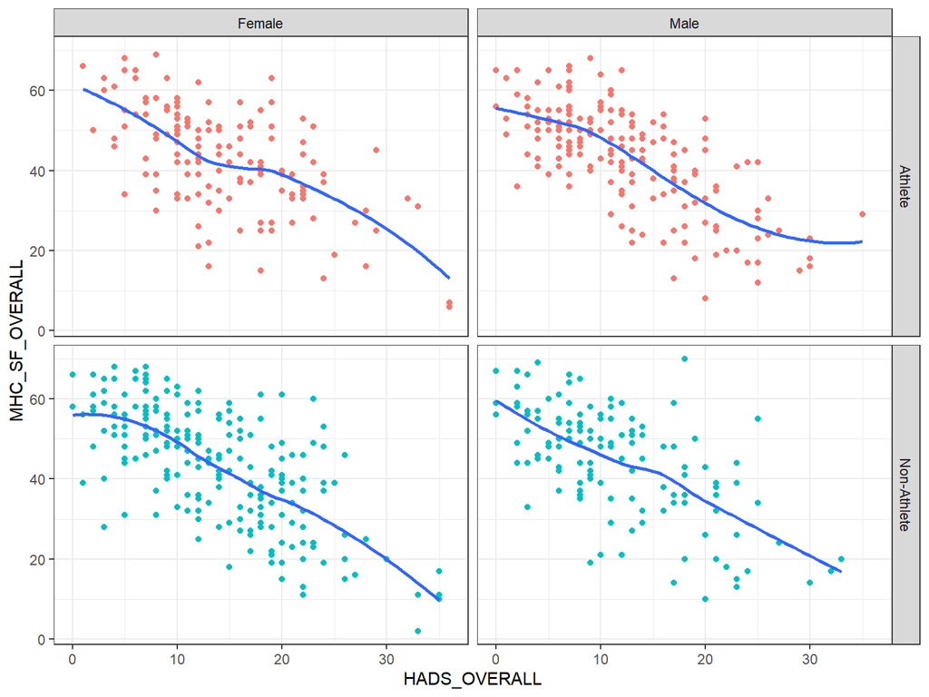

Anxiety & Depression

MHC_SF ~ LONE

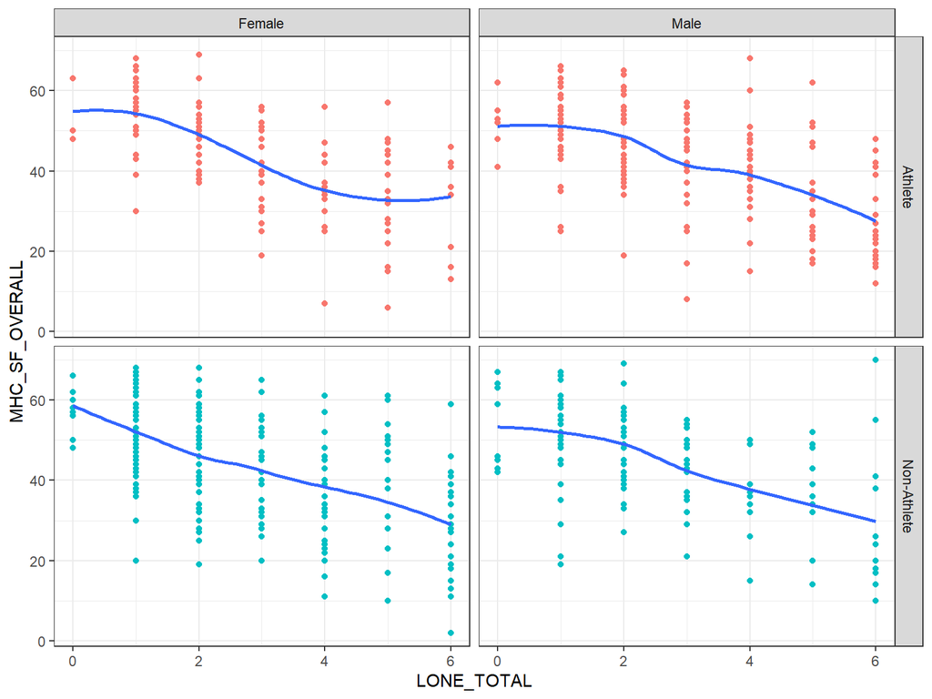

Loneliness Index

Both are negatively correlated with MHC_SF.

# Collinearity

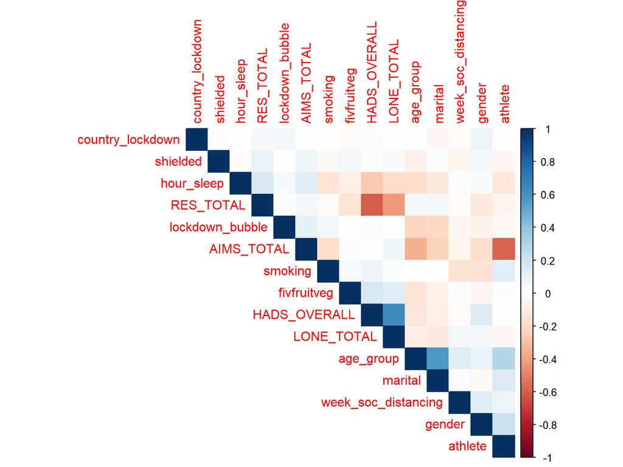

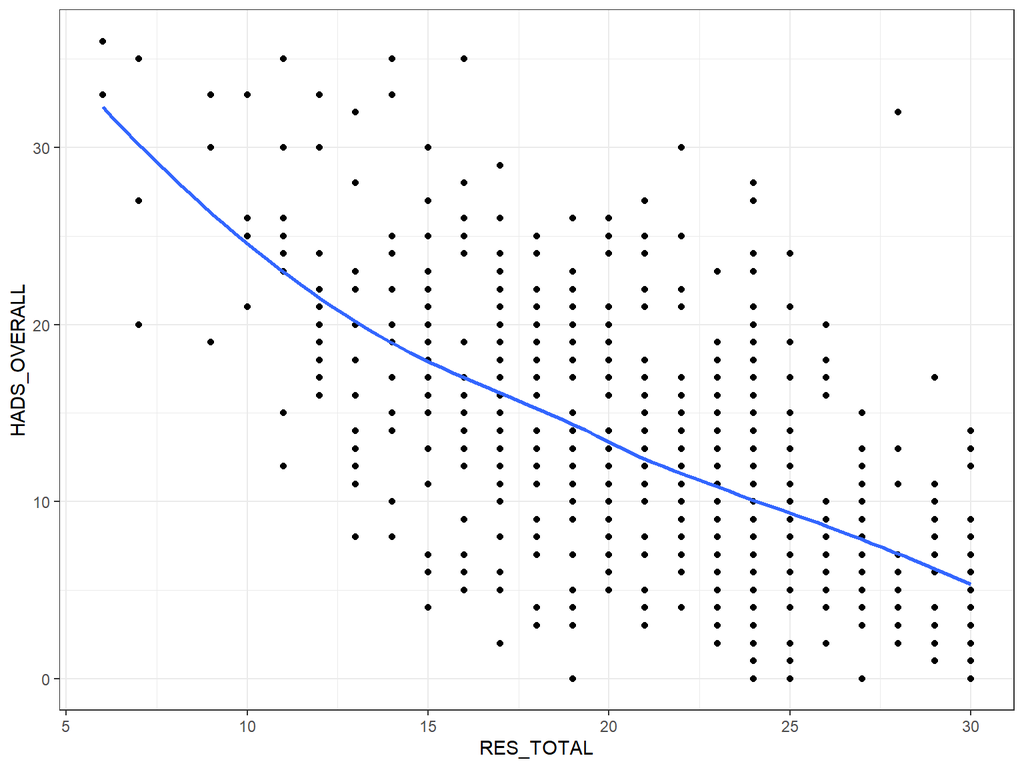

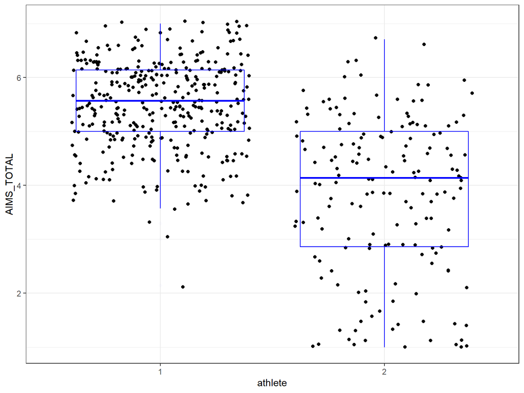

# Model Selection

- stepwise model-selection
  - using ‘step’ function in R
- Removing variables with Collinearity Issues
  - AIMS & athlete: ‘AIMS’ is deleted by the stepwise selection
  - RES & HADS: using AIC criterion, we delete ‘RES’
- possible interaction?
  - Not exist. (through F-test)

```
## Analysis of Variance Table
##
## Model 1: MHC_SF_OVERALL ~ gender + age_group + week_soc_distancing + athlete +
##     HADS_OVERALL + LONE_TOTAL
## Model 2: MHC_SF_OVERALL ~ (gender + age_group + week_soc_distancing +
##     athlete + HADS_OVERALL + +LONE_TOTAL)^2
##   Res.Df   RSS Df Sum of Sq      F Pr(>F)
## 1    439 36033
## 2    357 28625 82    7407.7 1.1267  0.232
```

# ANCOVA Model

After the model selection procedure, we set

$$\begin{align*}
y_{i} = &\mu
+ \beta_{1}I_{gender=2}(x_i)
+ \sum_{j=2}^7\beta_{2j}I_{\text{age grp}=j}(x_{2i}) \\
&+ \sum_{j=1}^7 \beta_{9_j}I_{\text{wk soc dist}=j}(x_{9i})
+ \beta_10 I_{\text{athlete}=2}(x_{10i}) \\
&+ \beta_{13} x_{13i}
+ \beta_{15} x_{15i}
+ \epsilon_i \\
\end{align*}$$

where $\epsilon ~ N(0,\sigma^2)$, and

- $I_A$s are indicator variables ($I_A(x)= 1$ if $x \in A$, or $0$ otherwise)
- $x_{13i}$: HADS of i-th point
- $x_{15i}$: LONE

# ANCOVA Model: Fitting

```
##
## Call:
## lm(formula = MHC_SF_OVERALL ~ gender + age_group + week_soc_distancing +
##     athlete + HADS_OVERALL + LONE_TOTAL, data = data[complete.cases(data),
##     ])
##
## Residuals:
##      Min       1Q   Median       3Q      Max
## -25.5832  -6.0533   0.3764   6.0016  28.8624
##
## Coefficients:
##                      Estimate Std. Error t value Pr(>|t|)
## (Intercept)           61.5207     3.5142  17.506  < 2e-16 ***
## gender2                2.7168     0.9030   3.009 0.002774 **
## age_group2             1.7070     1.4513   1.176 0.240143
## age_group3             2.0913     1.5084   1.386 0.166319
## age_group4             4.1729     1.5798   2.641 0.008551 **
## age_group5             2.6757     1.9126   1.399 0.162516
## age_group6             9.2206     2.7756   3.322 0.000968 ***
## age_group7             5.1999     4.3121   1.206 0.228509
## week_soc_distancing1 -11.4087     6.1747  -1.848 0.065326 .
## week_soc_distancing2   2.1181     3.9712   0.533 0.594041
## week_soc_distancing3  -2.9068     3.6286  -0.801 0.423530
## week_soc_distancing4  -2.0447     3.3612  -0.608 0.543298
## week_soc_distancing5  -4.2535     3.2906  -1.293 0.196825
## week_soc_distancing6  -2.8842     3.4072  -0.846 0.397735
## week_soc_distancing7   0.5698     3.5066   0.162 0.870998
## athlete2              -2.7065     0.9974  -2.714 0.006918 **
## HADS_OVERALL          -0.8756     0.0774 -11.313  < 2e-16 ***
## LONE_TOTAL            -2.5063     0.3127  -8.015    1e-14 ***
## ---
## Signif. codes:  0 '***' 0.001 '**' 0.01 '*' 0.05 '.' 0.1 ' ' 1
##
## Residual standard error: 9.06 on 439 degrees of freedom
## Multiple R-squared:  0.5754, Adjusted R-squared:  0.5589
## F-statistic: 34.99 on 17 and 439 DF,  p-value: < 2.2e-16
```

```r
final_model %>% Anova()
```

```
## Anova Table (Type II tests)
##
## Response: MHC_SF_OVERALL
##                     Sum Sq  Df  F value    Pr(>F)
## gender                 743   1   9.0525  0.002774 **
## age_group             1258   6   2.5549  0.019223 *
## week_soc_distancing   1588   7   2.7639  0.008061 **
## athlete                604   1   7.3635  0.006918 **
## HADS_OVERALL         10505   1 127.9850 < 2.2e-16 ***
## LONE_TOTAL            5273   1  64.2419 1.004e-14 ***
## Residuals            36033 439
## ---
## Signif. codes:  0 '***' 0.001 '**' 0.01 '*' 0.05 '.' 0.1 ' ' 1
```

# ANCOVA Model: Diagnosis

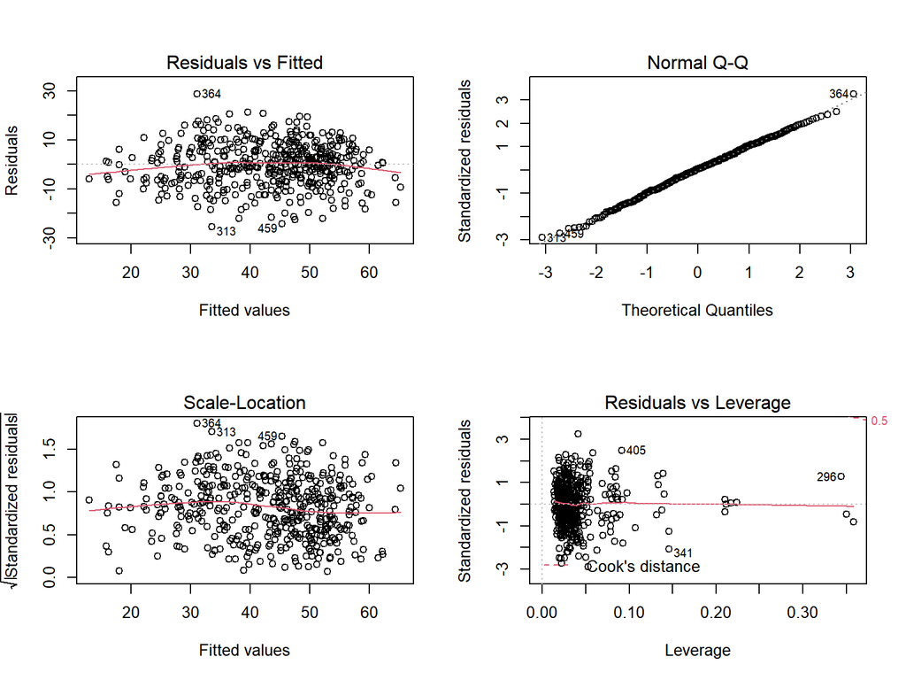

# Outlier?

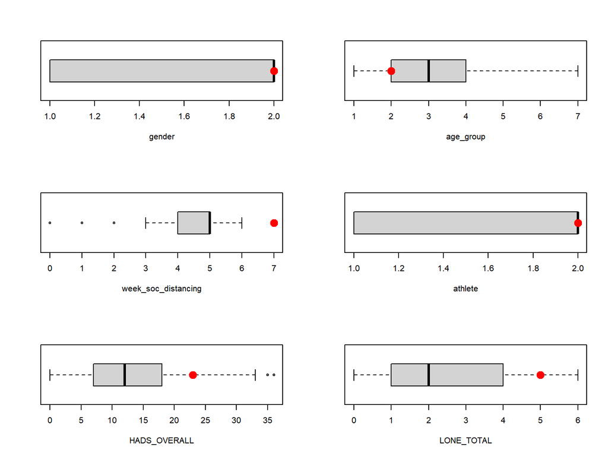

# Heteroskedasticity?

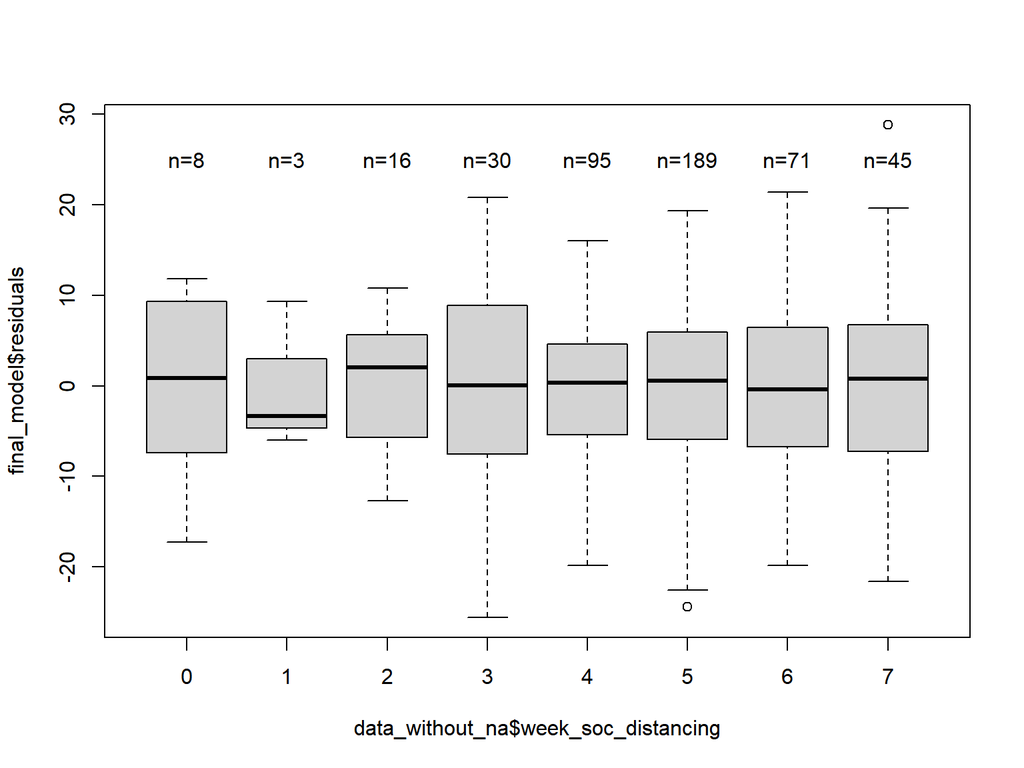

# High Leverage?

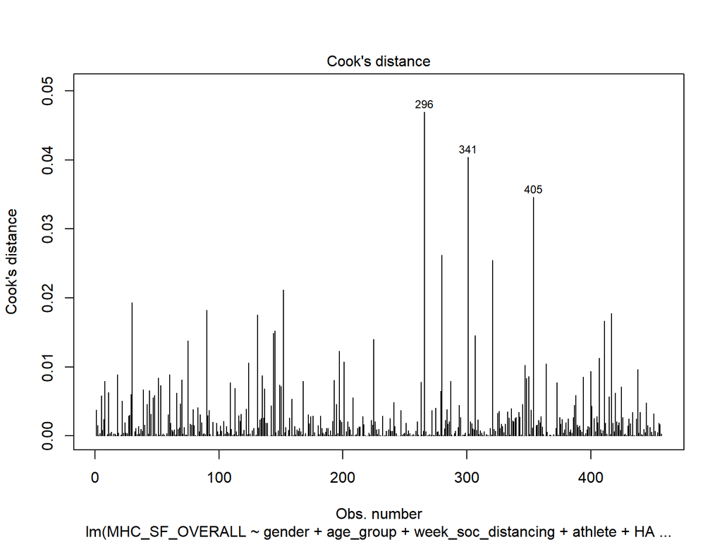

# Grouped Lasso Model

$$\begin{align*}
y_{i} = &\mu
+ \beta_{1}I_{gender=2}(x_i)
+ \sum_{j=2}^7\beta_{2j}I_{\text{age grp}=j}(x_{2i})
+ \sum_{j=2}^7\beta_{3j}I_{\text{country lockdown}=j}(x_{3i}) \\
&+ \sum_{j=2}^5\beta_{4j}I_{\text{marital}=j}(x_{4i})
+ \sum_{j=2}^7\beta_{5j}I_{\text{smoking}=j}(x_{5i})
+ \beta_{6}I_{\text{fruits}=2}(x_{6i}) \\
&+ \beta_{7} x_{7i}
+ \beta_{8}I_{\text{shielded}=2}(x_{8i})
+ \sum_{j=1}^7 \beta_{9_j}I_{\text{wk soc dist}=j}(x_{9i})
+ \beta_{10} I_{\text{athlete}=2}(x_{10i}) \\
&+ \beta_{11} x_{11i}
+ \beta_{12} x_{12i}
+ \beta_{13} x_{13i}
+ \beta_{14} x_{14i}
+ \beta_{15} x_{15i}
+ \epsilon_i
\\
\end{align*}$$

where

- $I_A$s are indicator variables, ($I_A(x)= 1$ if $x \in A$, or $0$ otherwise)
- $x_{7i}$: hour_sleep of the i-th observation
- Likewise, $x_{11i}$: lockdown_bubble, $x_{12i}$: AIMS, $x_{13i}$: HADS, $x_{14i}$: RES, and $x_{15i}$: LONE

with an error term $\epsilon_i$.

# Grouped Lasso: Fitting

- Setting each category and each continuous variable to its own group.
- Notation
  - $\mathbf{X}^{(g)} = (\mathbf{X}_{g1}, \mathbf{X}_{g2}, ..., \mathbf{X}_{gp_g})$
  - $\beta^{(g)} = (\beta_{g1}, \beta_{g2}, ..., \beta_{gp_g})^T.$

Then our objective function for grouped LASSO is:
$$\big | \big|y-\sum_{g=1}^G \mathbf{X}^{(g)}\beta^{(g)} \big |\big|_2^2 + \lambda \sum_{g=1}^G \sqrt{p_g}||\beta^{(g)}||_{2}$$

# Choosing $\lambda$ with 10-fold CV

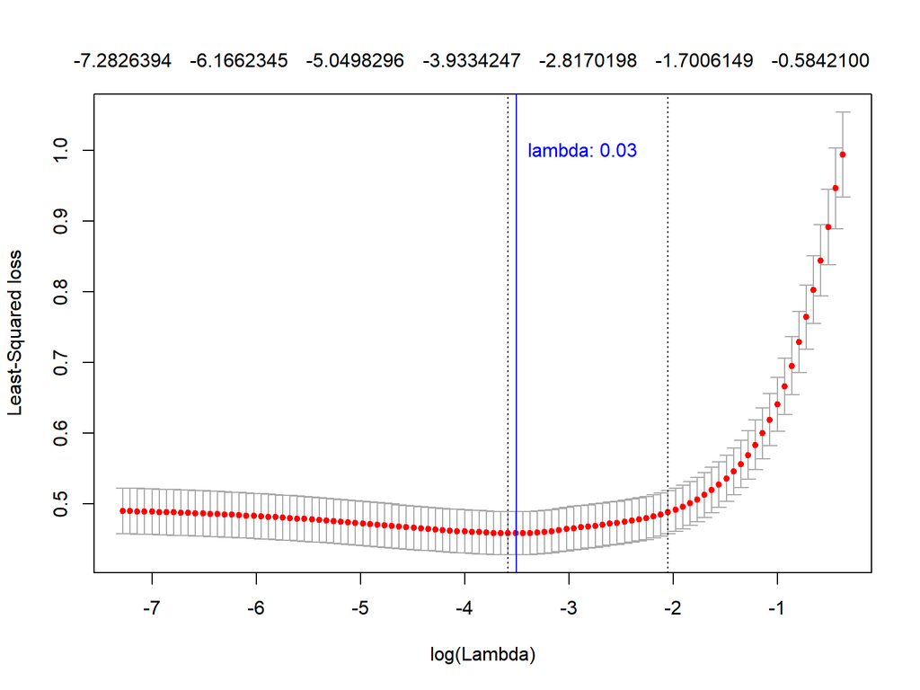

# $\lambda$ vs coefficients

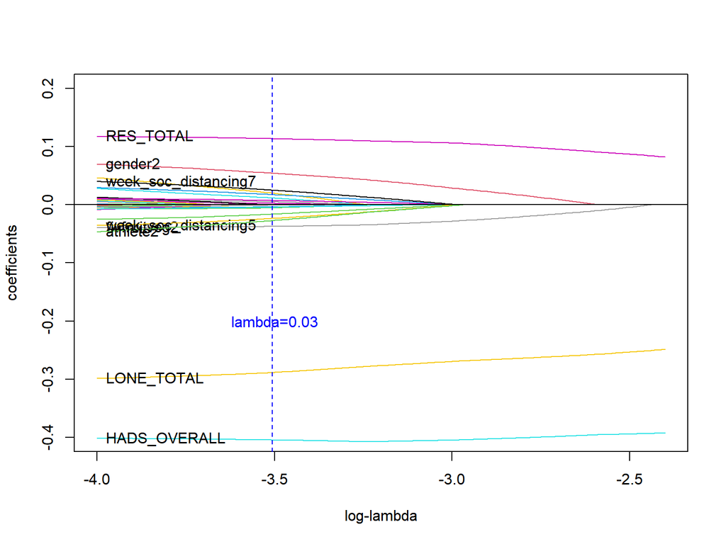

# Grouped Lasso: Fitting Result

```r
library(gglasso)
model_full_lasso_fit <- gglasso(
    design_matrix_full, response_full,
    lambda = 0.03,
    group = model_full_col_group, loss = "ls")
```

```r
coeff_lasso[1:20, ] %>% as.data.frame()
```

```
##                        .
## (Intercept)        0.000
## gender2            0.054
## age_group2        -0.006
## age_group3        -0.004
## age_group4         0.011
## age_group5         0.002
## age_group6         0.020
## age_group7         0.005
## country_lockdown2  0.000
## country_lockdown3  0.000
## country_lockdown4  0.000
## country_lockdown5  0.000
## country_lockdown7  0.000
## marital2           0.000
## marital3           0.000
## marital4           0.000
## marital5           0.000
## smoking2           0.000
## smoking3           0.000
## smoking4           0.000
```

```r
coeff_lasso[21:39, ] %>% as.data.frame()
```

```
##                           .
## smoking5              0.000
## smoking6              0.000
## smoking7              0.000
## fivfruitveg2         -0.038
## hour_sleep            0.000
## shielded2             0.000
## week_soc_distancing1 -0.016
## week_soc_distancing2  0.017
## week_soc_distancing3 -0.005
## week_soc_distancing4  0.007
## week_soc_distancing5 -0.024
## week_soc_distancing6 -0.001
## week_soc_distancing7  0.025
## lockdown_bubble       0.000
## athlete2             -0.027
## AIMS_TOTAL            0.000
## HADS_OVERALL         -0.404
## RES_TOTAL             0.113
## LONE_TOTAL           -0.288
```

# Grouped Lasso Model (Revisited)

$$\begin{align*}
y_{i} = &\mu
+ \beta_{1}I_{gender=2}(x_i)
+ \sum_{j=2}^7\beta_{2j}I_{\text{age grp}=j}(x_{2i})
+ \beta_{6}I_{\text{fruits}=2}(x_{6i})
+ \sum_{j=1}^7 \beta_{9_j}I_{\text{wk soc dist}=j}(x_{9i}) \\
&+ \beta_{10} I_{\text{athlete}=2}(x_{10i})
+ \beta_{13} x_{13i}
+ \beta_{14} x_{14i}
+ \beta_{15} x_{15i}
+ \epsilon_i
\\
\end{align*}$$

where

- $I_A$s are indicator variables, ($I_A(x)= 1$ if $x \in A$, or $0$ otherwise)
- $x_{13i}$: HADS
- $x_{14i}$: RES
- $x_{15i}$: LONE

with an error term $\epsilon_i$.

# ANCOVA vs Grouped Lasso

- ANCOVA gives
  - MHC_SF_OVERALL ~ gender + age_group + week_soc_distancing + athlete + HADS_OVERALL + LONE_TOTAL
- Group Lasso gives
  - MHC_SF_OVERALL ~ gender + age_group + fivfruitveg + week_soc_distancing + athlete + HADS_OVERALL + RES_TOTAL + LONE_TOTAL

# Discussion

Any questions? Comments? Suggestions?